# Analysis for ‘Novel object recognition in Trinidadian guppies’

My File Drawer [GitHub](https://github.com/wyatt-toure/file-drawer-research)

Guppy novel object recognition Guppy colour learning v1

Guppy novel object recognition Guppy colour learning v1

Home

M. Wyatt Toure

McGill University, Department of Biology, 1205 Docteur Penfield, Montreal, Quebec H3A 1B1, Canada

e-mail: `m_wyatt.toure@mail.mcgill.ca`

## General methods

In this experiment I exposed guppies to a two phase preference experiment. In phase 1 guppies were placed in a test tank and presented with two duplicates of a familiar object they had been exposed to in their home tanks for the past 24 hours. In the second phase after, being held in a separate tank for 1 minute, guppies were re-introduced into the test tank and either the left or the right duplicate of the familiar object had been replaced with a novel object. I wanted to see whether guppies treated this novel object differently from how they treated the familiar object in that same spot during the last trial.

## Models

The response metric I used was the novel object preference taken as a proportion of time spent near the novel object over the familiar object. Note, for phase 1 this response is coded based on where the novel object would be in phase 2. For example, let us say that the novel object was placed on the left side in phase 2. The response metric is then the following: In phase 1 the novel object preference is the time spent near the left object (a duplicate of the familiar object) and in phase 2 the novel object preference is the time spent near the left object (now a novel object). I looked at whether guppies were distinguishing novel objects behaviorally in two ways.

### Model 1 - Does the time spent with the object on the novel side change when a novel object is placed there

I first took the proportion of time spent with the object in the location where the novel object was going to be placed in the phase 2 test trial and compared it to the proportion of time spent in that location when a familiar object duplicate was placed there. If the tested guppy is more likely to engage with novelty *i.e.* neophilic, I would expect the proportion of time the guppy spends in the novel object location to increase when the novel object is there compared to when the familiar object is there. I used a quasibinomial generalized linear mixed model to investigate this and looked at whether the proportion of time spent near the left or right object changes when a novel object is placed there rather than a duplicate of the familiar object.

- **Response variable:** `novel.object.preference.proportion` is the time spent with the novel object divided by the total time spent near both objects.
- **Fixed effect:** `trial.type` denotes whether the trial is the first trial where both objects are duplicates of the familiar object or the second trial where one object has been replaced with a novel object.

```r
nor.model.1 <- glm(novel.object.preference.proportion ~ trial.type,
  data = my.data,
  family = "quasibinomial"
)
```

##### Results

| term | estimate | std.error | statistic | p.value |
| --- | --- | --- | --- | --- |
| (Intercept) | -0.066 | 0.16 | -0.414 | 0.681 |
| trial.typenovel | 0.569 | 0.23 | 2.469 | 0.018 |

There is a significant effect of trial type where, when the trial is the phase 2 trial with a novel object, guppies spend 14% more time near the object when it is novel compared to when it is a duplicate of the familiar object.

### Model 2 - Does the time spent with the novel object differ from 50%?

Additionally, I investigated whether, within the phase 2 trial, guppies were treating the novel object differently. I used a two sided t-test to compare the proportion of time near the novel object during the trial where there is one novel object and one familiar object against chance (50%).

```r
nor.model.2 <- t.test(novel.phase.data$novel.object.preference.proportion,
  mu = 0.5,
  alternative = "two.sided"
)
```

##### Results

```
    One Sample t-test

data:  novel.phase.data$novel.object.preference.proportion
t = 2.4462, df = 21, p-value = 0.02333
alternative hypothesis: true mean is not equal to 0.5
95 percent confidence interval:
 0.5184367 0.7276388
sample estimates:
mean of x
0.6230377
```

During the trial with a novel object, fish spent significantly more time near the novel object (p = 0.023). Guppies spent 62.3 % of their time with novel object over the familiar object

So we find that both across trials and within a trial there is an increase in preference for a novel object.

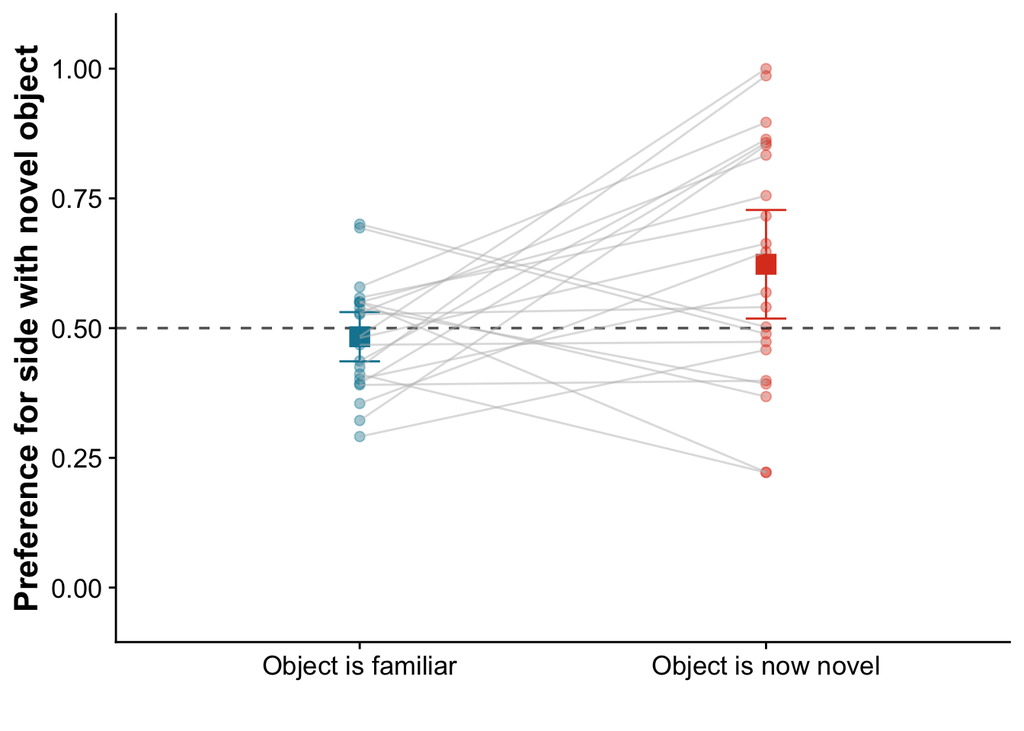

Figure 1: Data are means ± 95% confidence intervals. Lines connect individuals across trial types

## Additional Results

I used 4 different sets of objects. Including object type as an effect in the model does not reveal an effect of object type so it was dropped from the models above. Looking at the data with object type incorporated reveals that across all object types there is an increase in preference for an object when it is novel across all object types.

```r
esm.model.1 <- glm((novel.object.preference.proportion) ~ trial.type * object.type,
  data = my.data,
  family = "quasibinomial"
)
```

##### Results

| trial.type | object.type | fit | se | lower | upper |
| --- | --- | --- | --- | --- | --- |
| familiar | blue | 0.5232538 | 0.0861738 | 0.3526280 | 0.6886192 |
| novel | blue | 0.5825085 | 0.0850845 | 0.4069764 | 0.7393588 |
| familiar | green | 0.4742661 | 0.0786464 | 0.3224074 | 0.6310391 |
| novel | green | 0.6905221 | 0.0728088 | 0.5278666 | 0.8166091 |
| familiar | grey | 0.4230069 | 0.0778115 | 0.2774774 | 0.5832491 |
| novel | grey | 0.5366240 | 0.0785392 | 0.3789946 | 0.6872588 |
| familiar | purple | 0.5269576 | 0.0861417 | 0.3559661 | 0.6918507 |
| novel | purple | 0.6862823 | 0.0800544 | 0.5071723 | 0.8230136 |